# **Loan Default Prediction**

### **Building a Random Forest Classifier**

**Random Forest is a bagging algorithm where the base models are Decision Trees.** Samples are taken from the training data and on each sample a decision tree makes a prediction.

**The results from all the decision trees are combined together and the final prediction is made using voting or averaging.**

```python
# Fitting the Random Forest classifier on the training data
rf = RandomForestClassifier(criterion='entropy', random_state=1)

rf.fit(x_train, y_train)
```

```
RandomForestClassifier(criterion='entropy', random_state=1)
```

```
              precision    recall  f1-score   support

           0       1.00      1.00      1.00      3323
           1       1.00      1.00      1.00       831

    accuracy                           1.00      4154
   macro avg       1.00      1.00      1.00      4154
weighted avg       1.00      1.00      1.00      4154
```

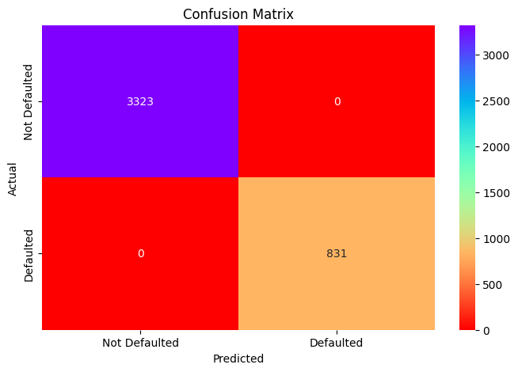

```python
# Checking performance on the training data
y_pred_train_rf = rf.predict(x_train)

metrics_score(y_train, y_pred_train_rf)
```

```
              precision    recall  f1-score   support

           0       0.91      0.99      0.95      1424
           1       0.92      0.63      0.75       357

    accuracy                           0.92      1781
   macro avg       0.92      0.81      0.85      1781
weighted avg       0.92      0.92      0.91      1781
```

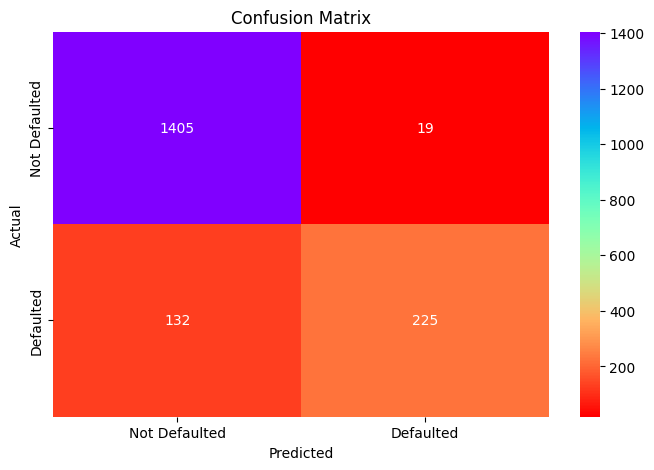

```
Total expected revenue: 5562403.12055 with confidence of: 0.9220488626790229
```

```python
# Checking the performance on the test data
model_metrics.loc[len(model_metrics)] = evaluate_model_and_metrics(rf, x_test, y_test, X_scaled, default_model, 'rf', 'Random Forest')
```

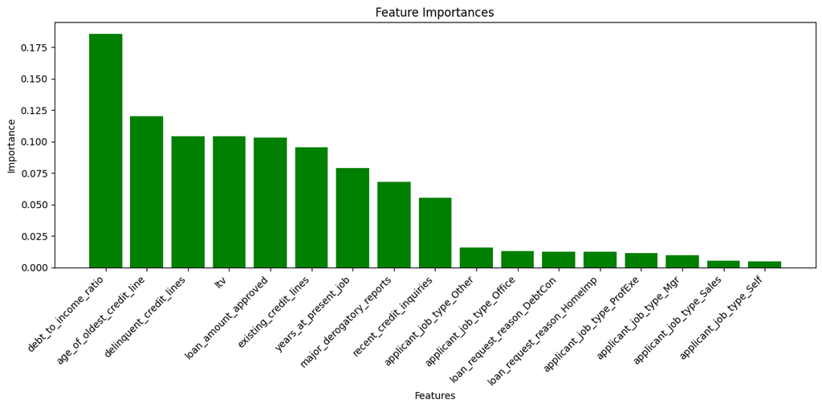

```python
plot_feature_importances_or_coefficients(rf, X)
```

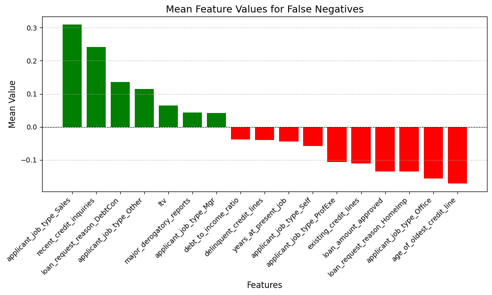

```python
analyze_subset_features(
    model=rf,
    x_test=x_test,
    y_test=y_test,
    subset='false_negatives'
)
```

### **Random Forest Classifier Hyperparameter Tuning**

```
Optimizing for: accuracy
Fitting 5 folds for each of 972 candidates, totalling 4860 fits
Best Parameters for accuracy: {'bootstrap': False, 'criterion': 'gini', 'max_depth': None, 'max_features': 'sqrt', 'min_samples_leaf': 1, 'min_samples_split': 5, 'n_estimators': 100}
Best Cross-Validation Score for accuracy: 0.9193565598132603
              precision    recall  f1-score   support

           0       0.92      0.98      0.95      1424
           1       0.90      0.68      0.78       357

    accuracy                           0.92      1781
   macro avg       0.91      0.83      0.86      1781
weighted avg       0.92      0.92      0.92      1781
```

```
Total expected revenue: 6276275.258959028 with confidence of: 0.9442840494243192
Optimizing for: f1
Fitting 5 folds for each of 972 candidates, totalling 4860 fits
Best Parameters for f1: {'bootstrap': False, 'criterion': 'gini', 'max_depth': None, 'max_features': 'sqrt', 'min_samples_leaf': 1, 'min_samples_split': 5, 'n_estimators': 100}
Best Cross-Validation Score for f1: 0.7640976248382408
              precision    recall  f1-score   support

           0       0.92      0.98      0.95      1424
           1       0.90      0.68      0.78       357

    accuracy                           0.92      1781
   macro avg       0.91      0.83      0.86      1781
weighted avg       0.92      0.92      0.92      1781
```

```
Total expected revenue: 6276275.258959028 with confidence of: 0.9442840494243192
Optimizing for: recall
Fitting 5 folds for each of 972 candidates, totalling 4860 fits
Best Parameters for recall: {'bootstrap': False, 'criterion': 'gini', 'max_depth': None, 'max_features': 'sqrt', 'min_samples_leaf': 1, 'min_samples_split': 5, 'n_estimators': 100}
Best Cross-Validation Score for recall: 0.6534521318808166
              precision    recall  f1-score   support

           0       0.92      0.98      0.95      1424
           1       0.90      0.68      0.78       357

    accuracy                           0.92      1781
   macro avg       0.91      0.83      0.86      1781
weighted avg       0.92      0.92      0.92      1781
```

```
Total expected revenue: 6276275.258959028 with confidence of: 0.9442840494243192
Optimizing for: precision
Fitting 5 folds for each of 972 candidates, totalling 4860 fits
Best Parameters for precision: {'bootstrap': True, 'criterion': 'gini', 'max_depth': 10, 'max_features': 'sqrt', 'min_samples_leaf': 1, 'min_samples_split': 2, 'n_estimators': 500}
Best Cross-Validation Score for precision: 0.9433214911588138
              precision    recall  f1-score   support

           0       0.89      0.99      0.94      1424
           1       0.95      0.52      0.67       357

    accuracy                           0.90      1781
   macro avg       0.92      0.76      0.81      1781
weighted avg       0.90      0.90      0.89      1781
```

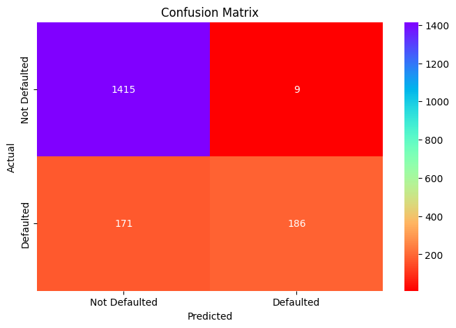

```
Total expected revenue: 3285727.1729790894 with confidence of: 0.8622348210410206
```

```python
# Define the Random Forest model
rf_estimator_grid = RandomForestClassifier(random_state=1)

# Define the parameter grid to search over
param_grid = {
    'criterion': ['gini', 'entropy'],
    'n_estimators': [100, 200, 500],
    'max_depth': [10, 20, None],
    'min_samples_split': [2, 5, 10],
    'min_samples_leaf': [1, 2, 5],
    'max_features': ['sqrt', 'log2', 0.5],
    'bootstrap': [True, False]
}

# Initialize results dictionary and DataFrame
results = {}

# Perform GridSearchCV for each scoring metric
for opt in optimum:
    print(f"Optimizing for: {opt}")

    # Set up GridSearchCV
    grid_search = GridSearchCV(
        estimator=rf_estimator_grid,
        param_grid=param_grid,
        scoring=opt,
        cv=5,
        n_jobs=-1,
        verbose=1
    )

    # Perform the grid search on the training data
    grid_search.fit(x_train, y_train)

    # Store best parameters and cross-validation score
    results[opt] = {
        'best_params': grid_search.best_params_,
        'best_score': grid_search.best_score_,
        'best_model': grid_search.best_estimator_
    }

    print(f"Best Parameters for {opt}: {results[opt]['best_params']}")
    print(f"Best Cross-Validation Score for {opt}: {results[opt]['best_score']}")

    # Evaluate the best model and append results
    model_metrics.loc[len(model_metrics)] = evaluate_model_and_metrics(results[opt]['best_model'], x_test, y_test, X_scaled, default_model, f'rf_estimator_grid_{opt}', 'Random Forest', grid_search=True)
```

```python
# Trigger garbage collection and print the number of objects collected
collected_objects = gc.collect()
print(f"Garbage collector freed {collected_objects} objects.")
```

```
Garbage collector freed 99875 objects.
```

#### Observation:

Tuned RF models are the best-performing among all the models so far, and is giving us scores on the test dataset.

**Model Comparision based on expected revenue and confidence level**

```python
model_metrics
```

|  | Model Name | Model Type | Grid Search (Yes/No) | Recall | Precision | f1 | Accuracy | FPs | FNs | Revenue Prediction | Confidence |
| --- | --- | --- | --- | --- | --- | --- | --- | --- | --- | --- | --- |
| 0 | lg | Logistic Regression | No | 0.274510 | 0.748092 | 0.401639 | 0.836047 | 33 | 259 | 2.698671e+06 | 0.837825 |
| 1 | log_reg_accuracy | Logistic Regression | Yes | 0.274510 | 0.759690 | 0.403292 | 0.837170 | 31 | 259 | 2.668632e+06 | 0.837108 |
| 2 | log_reg_f1 | Logistic Regression | Yes | 0.274510 | 0.748092 | 0.401639 | 0.836047 | 33 | 259 | 2.694613e+06 | 0.837809 |
| 3 | log_reg_recall | Logistic Regression | Yes | 0.274510 | 0.748092 | 0.401639 | 0.836047 | 33 | 259 | 2.694613e+06 | 0.837809 |
| 4 | log_reg_precision | Logistic Regression | Yes | 0.182073 | 0.783133 | 0.295455 | 0.825940 | 18 | 292 | 1.760434e+06 | 0.819371 |
| 5 | dt | Decision Tree | No | 0.565826 | 0.675585 | 0.615854 | 0.858506 | 97 | 155 | 7.501718e+06 | 1.000000 |
| 6 | dtree_estimator_grid_accuracy | Decision Tree | Yes | 0.591036 | 0.674121 | 0.629851 | 0.860752 | 102 | 146 | 7.346832e+06 | 0.995723 |
| 7 | dtree_estimator_grid_f1 | Decision Tree | Yes | 0.591036 | 0.674121 | 0.629851 | 0.860752 | 102 | 146 | 7.346832e+06 | 0.995723 |
| 8 | dtree_estimator_grid_recall | Decision Tree | Yes | 0.565826 | 0.629283 | 0.595870 | 0.846154 | 119 | 155 | 7.458708e+06 | 1.000000 |
| 9 | dtree_estimator_grid_precision | Decision Tree | Yes | 0.459384 | 0.803922 | 0.584670 | 0.869175 | 40 | 193 | 4.874592e+06 | 0.911351 |
| 10 | rf | Random Forest | No | 0.630252 | 0.922131 | 0.748752 | 0.915216 | 19 | 132 | 5.562403e+06 | 0.922049 |
| 11 | rf_estimator_grid_accuracy | Random Forest | Yes | 0.680672 | 0.900000 | 0.775120 | 0.920831 | 27 | 114 | 6.276275e+06 | 0.944284 |
| 12 | rf_estimator_grid_f1 | Random Forest | Yes | 0.680672 | 0.900000 | 0.775120 | 0.920831 | 27 | 114 | 6.276275e+06 | 0.944284 |
| 13 | rf_estimator_grid_recall | Random Forest | Yes | 0.680672 | 0.900000 | 0.775120 | 0.920831 | 27 | 114 | 6.276275e+06 | 0.944284 |
| 14 | rf_estimator_grid_precision | Random Forest | Yes | 0.521008 | 0.953846 | 0.673913 | 0.898933 | 9 | 171 | 3.285727e+06 | 0.862235 |

Overall performance is better for tree based models in comparision with logistic regression. This points to non-linearity in the dataset and existence of outliers, both of which are handled very effectievely by tree based models.

There is of course room for improvement in all of the above models by fine tuning the hyperparameters to focus on reducing False Negatives (while not overly sacrificing the recall), as the cost of False Negatives is substantially higher than False positives (i.e. False negatives cost the lender the principle and the interest whereas False positives cost the lender only the interest). This can be achieved by adjusting the weights and fine tuning the threshold to penalize False Negatives more than False Positives.

**2. Refined insights and recommandations:**

1. Improve Data Quality and capture additional data
> - Encourage applicants to provide missing details, such as job_type and loan_request_reason
> - Use dropdowns and predefined options for categorical data like job_type to minimize typos and inconsistencies.
> - Include gross income and monthly expenses to calculate a more accurate debt-to-income ratio, as this is the most important factor in determining eligibility
> - Collect data on savings, investment portfolios, and other assets to assess overall financial stability
> - Obtain credit scores and histories from reputable bureaus to ensure a consistent, accurate representation of creditworthiness
2. Remove bias in the dataset
> - Ensure that all demographic groups and professions are fairly represented in the data to avoid skewing results
> - Reduce overrepresentation of risky loan types (e.g., debt consolidation loans) by diversifying the dataset
3. Business model
> - Gather borrower feedback on application processes and loan terms to identify areas for business improvement
> - Use the model to identify high-risk borrower segments (e.g., high debt-to-income ratios, multiple derogatory reports)
> - Higher interest rates or stricter loan limits for high-risk borrowers
> - Discounts or incentives for low-risk borrowers
> - Offer customized repayment options for borrowers facing temporary financial difficulties
> - Regular evaluation of bias and fairness to ensure legal and ethical compliance

**Summary** The loan default problem is heavily influenced by credit history, debt burden, and dataset biases (e.g., debt consolidation). The most effective strategies will involve:

> - Robust feature engineering to balance stabilizing and risk-indicating factors.
> - Careful tuning of decision thresholds and class weights to minimize false negatives without inflating false positives.

**3. Proposal for the final solution design:**

> - Improve model accuracy and robustness by reducing bias and missing information
> - Ensures fair and personalized loan offerings, improving customer satisfaction
> - Reduces legal and ethical risks by eliminating discriminatory practices
> - Helps mitigate default risk and increases profitability

## Threshold optimization for the chosen model

```python
# Recreate the best model - rf_estimator_grid_recall, with the same parameters from gridsearch

# Define the model
rf_estimator_best = RandomForestClassifier(
    bootstrap=False,
    criterion='gini',
    max_depth=None,
    max_features='sqrt',
    min_samples_leaf=1,
    min_samples_split=5,
    n_estimators=100,
    random_state=1,
    n_jobs=-1
)

# Perform cross-validation
cv_scores = cross_val_score(rf_estimator_best, x_train, y_train, cv=5, scoring='recall')
print("Cross-Validation Scores:", cv_scores)
print("Mean CV Score:", cv_scores.mean())

# Fit the model on the entire training dataset
rf_estimator_best.fit(x_train, y_train)

# Make predictions on the test set
y_tuned = rf_estimator_best.predict(x_test)

# Evaluate the predictions
recall = recall_score(y_test, y_tuned)
print("Recall Score on Test Set:", recall)
metrics_score(y_test, y_tuned)
```

```
Cross-Validation Scores: [0.63473054 0.65060241 0.62650602 0.68072289 0.6746988 ]
Mean CV Score: 0.6534521318808166
Recall Score on Test Set: 0.680672268907563
              precision    recall  f1-score   support

           0       0.92      0.98      0.95      1424
           1       0.90      0.68      0.78       357

    accuracy                           0.92      1781
   macro avg       0.91      0.83      0.86      1781
weighted avg       0.92      0.92      0.92      1781
```

```python
# Predict probabilities
y_probs_best = rf_estimator_best.predict_proba(x_test)[:, 1]
```

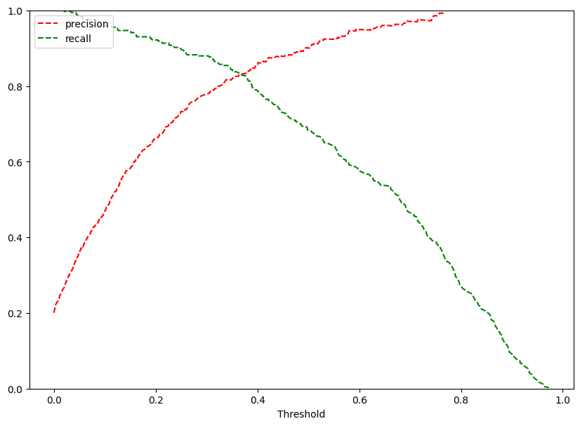

```python
# Compute precision-recall curve
precision, recall, thresholds = precision_recall_curve(y_test, y_probs_best)

# Plot values of precisions, recalls, and thresholds
plt.figure(figsize = (10, 7))
plt.plot(thresholds, precision[:-1], 'r--', label = 'precision')
plt.plot(thresholds, recall[:-1], 'g--', label = 'recall')
plt.xlabel('Threshold')
plt.legend(loc = 'upper left')
plt.ylim([0, 1])
plt.show()
```

```
7601235.5 1.0
              precision    recall  f1-score   support

           0       0.95      0.97      0.96      1424
           1       0.86      0.79      0.82       357

    accuracy                           0.93      1781
   macro avg       0.90      0.88      0.89      1781
weighted avg       0.93      0.93      0.93      1781
```

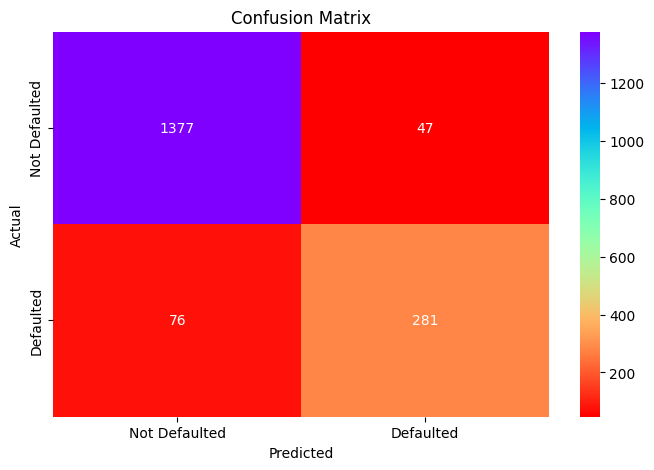

```python
# Adjust the threshold
threshold = 0.4  # based on the precision recall curve above

pred_prob_rf_best = rf_estimator_best.predict_proba(X_scaled)
pred_prob_rf_thrsh = (pred_prob_rf_best >= threshold).astype(int)
default_model_best = default_model.copy()
default_model_best['prob_default'] = pred_prob_rf_thrsh[:, 1]
revenue_best, confidencef_best = calculate_expected_with_confidence(default_model_best, 'loan_amount_approved')
print(revenue_best, confidencef_best)

y_pred_threshold = (y_probs_best >= threshold).astype(int)
metrics_score(y_test, y_pred_threshold)
```

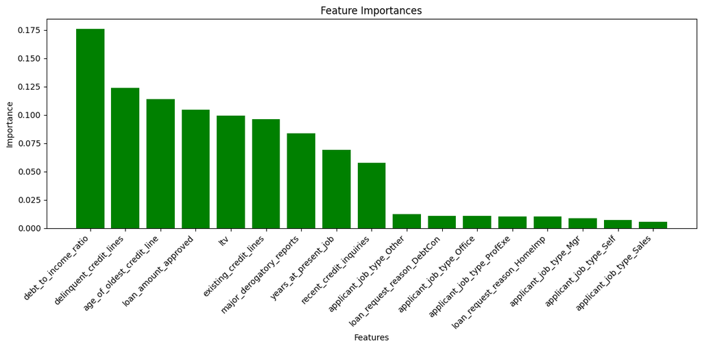

```python
plot_feature_importances_or_coefficients(rf_estimator_best, X)
```

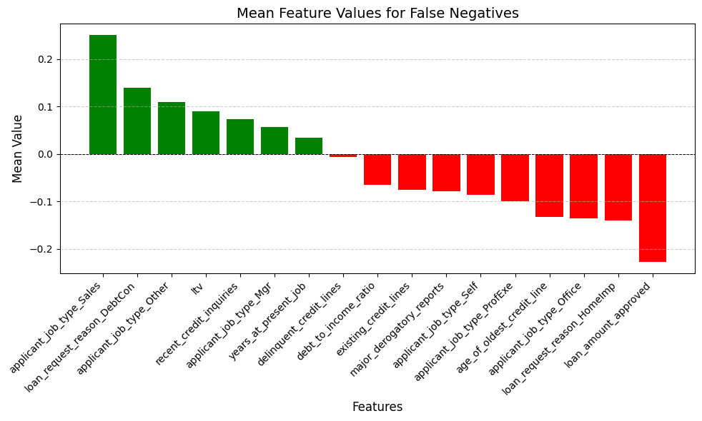

```python
analyze_subset_features(rf_estimator_best, x_test, y_test)
```

#### Observations

Adjusting the threshold has significantly improved performance for the recall and the revenue expectation.  
No of False negatives has gone down substantially, which is driving higher revenue expectation.  
Feature importances are similar as well as the features driving False Negatives

#### Let's try fine tuning the threshold between 0.3 to 0.5

```
Threshold: 0.3, Recall: 0.880, Revenue: 7537519.50
Threshold: 0.4, Recall: 0.787, Revenue: 7601235.50
Threshold: 0.5, Recall: 0.681, Revenue: 7622324.00
```

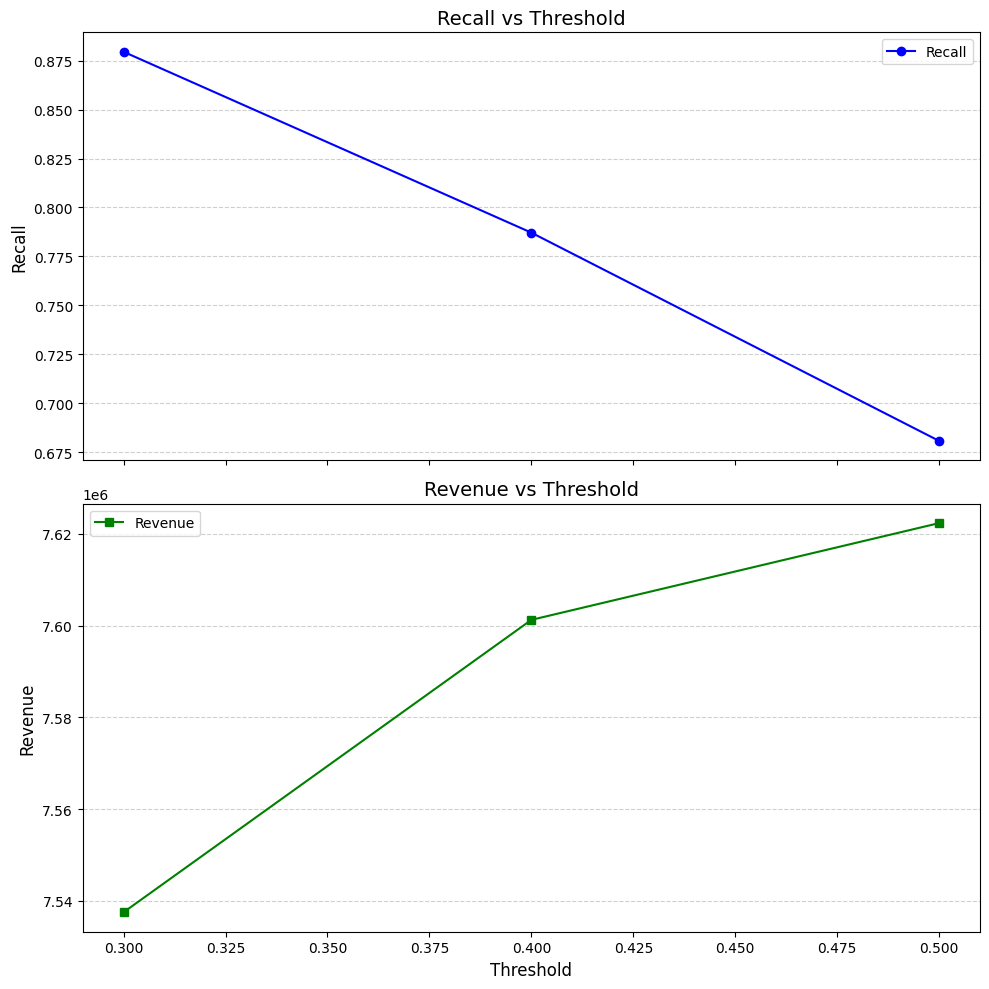

```python
import matplotlib.pyplot as plt
import numpy as np
from sklearn.metrics import recall_score

# Define the recall thresholds
recall_thresholds = np.arange(0.3, 0.6, 0.1)  # 0.3 to 0.5 with a step of 0.1

# Initialize lists to store results
recall_values = []
revenue_values = []

# Iterate over the thresholds
for threshold in recall_thresholds:
    # Predict probabilities on x_test and apply threshold
    pred_prob_rf_best = rf_estimator_best.predict_proba(x_test)
    y_pred_threshold = (pred_prob_rf_best[:, 1] >= threshold).astype(int)

    # Calculate recall
    recall = recall_score(y_test, y_pred_threshold)
    recall_values.append(recall)

    # Update the default_model dataset with threshold-based predictions
    default_model_best = default_model.copy()
    pred_prob_scaled = rf_estimator_best.predict_proba(X_scaled)
    default_model_best['prob_default'] = (pred_prob_scaled[:, 1] >= threshold).astype(int)

    # Calculate expected revenue
    revenue_best, _ = calculate_expected_with_confidence(default_model_best, 'loan_amount_approved')
    revenue_values.append(revenue_best)

    print(f"Threshold: {threshold}, Recall: {recall:.3f}, Revenue: {revenue_best:.2f}")

# Create subplots
fig, axes = plt.subplots(2, 1, figsize=(10, 10), sharex=True)

# Plot Recall
axes[0].plot(recall_thresholds, recall_values, marker='o', label='Recall', color='blue')
axes[0].set_title('Recall vs Threshold', fontsize=14)
axes[0].set_ylabel('Recall', fontsize=12)
axes[0].grid(axis='y', linestyle='--', alpha=0.6)
axes[0].legend()

# Plot Revenue
axes[1].plot(recall_thresholds, revenue_values, marker='s', label='Revenue', color='green')
axes[1].set_title('Revenue vs Threshold', fontsize=14)
axes[1].set_xlabel('Threshold', fontsize=12)
axes[1].set_ylabel('Revenue', fontsize=12)
axes[1].grid(axis='y', linestyle='--', alpha=0.6)
axes[1].legend()

# Adjust layout
plt.tight_layout()
plt.show()
```

#### Observation

Threshold = 0.4 for balances risk (recall of 0.787) and business goals (revenue of 7,601,235.50).  
It reduces extreme trade-offs, ensuring the model performs reliably without overly conservative or aggressive predictions, for future customers.

#### Try the XG Boost model for comparision with the best Random Forest model

```
   Precision    Recall  Accuracy
0   0.906748  0.828402  0.918585
Revenue (XGBoost Best Model): 7610806.5
Confidence (XGBoost Best Model): 1.0
              precision    recall  f1-score   support

           0       0.92      0.98      0.95      1424
           1       0.89      0.68      0.77       357

    accuracy                           0.92      1781
   macro avg       0.91      0.83      0.86      1781
weighted avg       0.92      0.92      0.91      1781
```

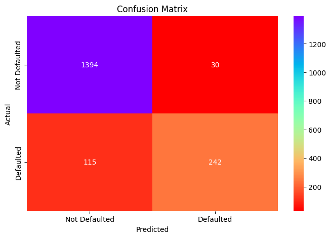

```python
# Importing the XGBClassifier from the xgboost library
from xgboost import XGBClassifier

# XGBoost Classifier
xgb = XGBClassifier(random_state = 1, eval_metric = 'logloss')

# Fitting the model
xgb.fit(x_train,y_train)

# Model Performance on the test data
xgb_perf_test = model_performance_classification(xgb,x_test,y_test)

print(xgb_perf_test)

# Predict probabilities for revenue prediction
pred_prob_xgb_best = xgb.predict_proba(X_scaled)
pred_prob_xgb_thrsh = (pred_prob_xgb_best >= 0.5).astype(int)

# Copy default model and add probabilities
default_model_best_xgb = default_model.copy()
default_model_best_xgb['prob_default'] = pred_prob_xgb_thrsh[:, 1]

# Calculate expected revenue and confidence
revenue_best_xgb, confidence_best_xgb = calculate_expected_with_confidence(
    default_model_best_xgb, 'loan_amount_approved'
)
print("Revenue (XGBoost Best Model):", revenue_best_xgb)
print("Confidence (XGBoost Best Model):", confidence_best_xgb)

metrics_score(y_test, xgb.predict(x_test))
```

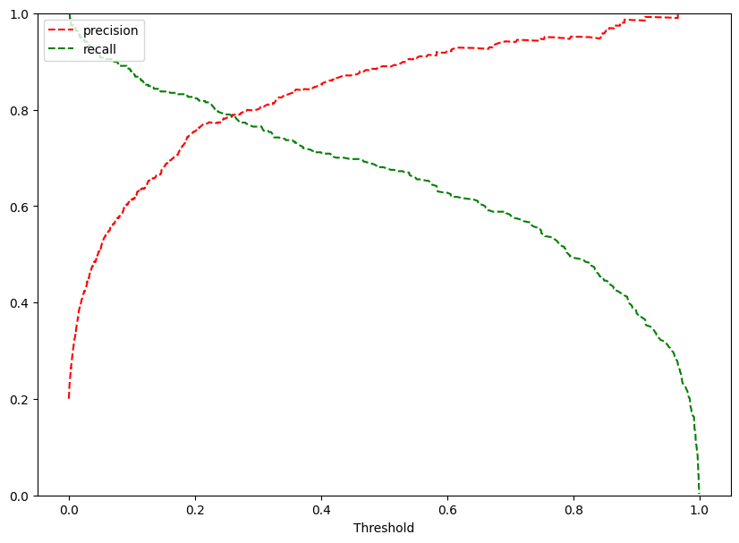

```python
# Predict probabilities
y_probs_xgb = xgb.predict_proba(x_test)[:, 1]

# Compute precision-recall curve
precision, recall, thresholds = precision_recall_curve(y_test, y_probs_xgb)

# Plot values of precisions, recalls, and thresholds
plt.figure(figsize = (10, 7))
plt.plot(thresholds, precision[:-1], 'r--', label = 'precision')
plt.plot(thresholds, recall[:-1], 'g--', label = 'recall')
plt.xlabel('Threshold')
plt.legend(loc = 'upper left')
plt.ylim([0, 1])
plt.show()
```

```
7610806.5 1.0
              precision    recall  f1-score   support

           0       0.92      0.98      0.95      1424
           1       0.89      0.68      0.77       357

    accuracy                           0.92      1781
   macro avg       0.91      0.83      0.86      1781
weighted avg       0.92      0.92      0.91      1781
```

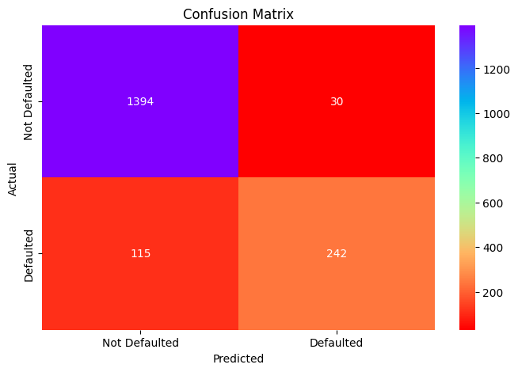

```python
# Adjust the threshold
threshold = 0.5  # based on the precision recall curve above

pred_prob_xgb = xgb.predict_proba(X_scaled)
pred_prob_xgb_thrsh = (pred_prob_xgb_best >= threshold).astype(int)
default_model_best = default_model.copy()
default_model_best['prob_default'] = pred_prob_xgb_thrsh[:, 1]
revenue_best, confidencef_best = calculate_expected_with_confidence(default_model_best, 'loan_amount_approved')
print(revenue_best, confidencef_best)

y_pred_threshold_xgb = (y_probs_xgb >= threshold).astype(int)
metrics_score(y_test, y_pred_threshold_xgb)
```

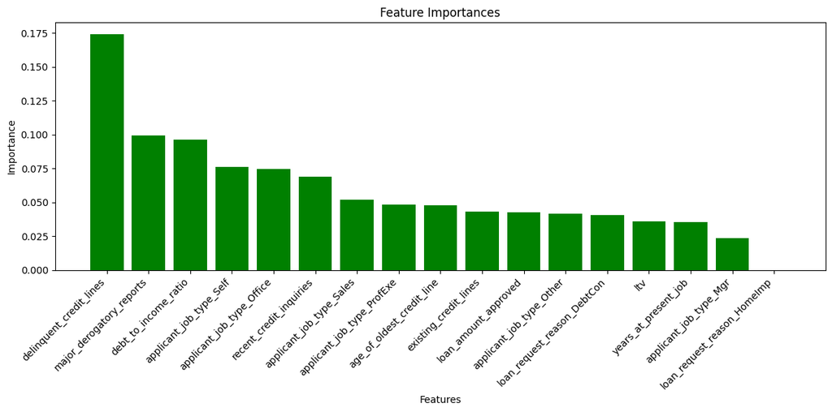

```python
plot_feature_importances_or_coefficients(xgb, X)
```

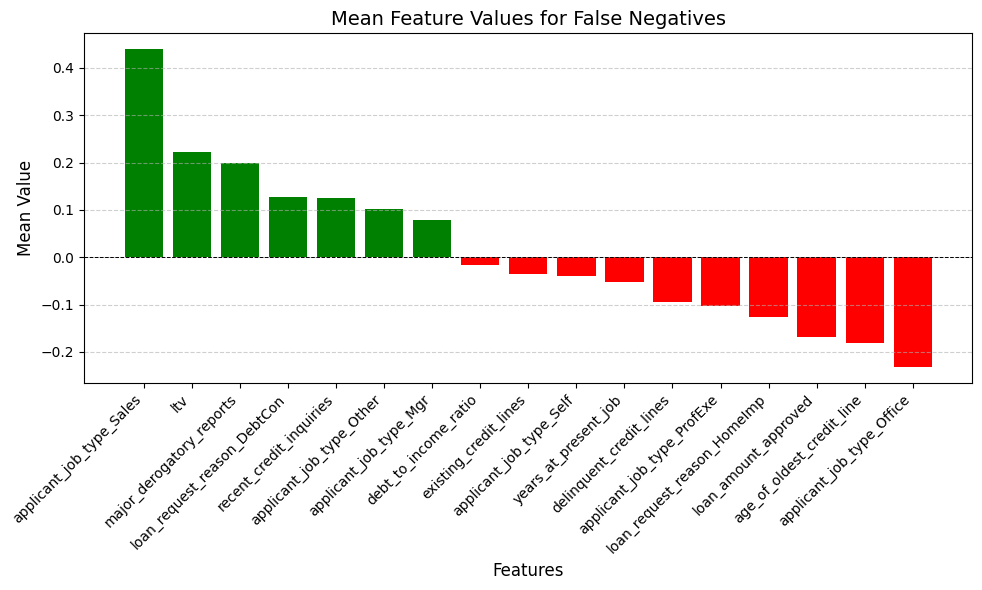

```python
analyze_subset_features(
    model=xgb,
    x_test=x_test,
    y_test=y_test,
    subset='false_negatives'
)
```

```python
# # Define the model
# xgb_grid = XGBClassifier(objective='binary:logistic', random_state=42, use_label_encoder=False, eval_metric='logloss')

# # Define the parameter grid
# param_grid = {
#     'n_estimators': [50, 100, 200],  # Number of boosting rounds
#     'learning_rate': [0.01, 0.1, 0.2],  # Step size shrinkage
#     'max_depth': [3, 5, 7],  # Maximum tree depth
#     'subsample': [0.8, 1.0],  # Subsampling ratio
#     'colsample_bytree': [0.8, 1.0],  # Subsampling ratio of columns
#     'gamma': [0, 0.1, 0.2],  # Minimum loss reduction
# }

# # Set up GridSearchCV
# grid_search = GridSearchCV(
#     estimator=xgb_grid,
#     param_grid=param_grid,
#     scoring='accuracy',  # Metric for evaluation (can be changed to f1, recall, etc.)
#     cv=5,  # 5-fold cross-validation
#     verbose=1,
#     n_jobs=-1  # Use all processors
# )

# # Perform the grid search
# grid_search.fit(x_train, y_train)

# # Display the best parameters and best score
# print("Best Parameters:", grid_search.best_params_)
# print("Best Cross-Validation Score:", grid_search.best_score_)

# # Evaluate the best model on the test set
# best_model = grid_search.best_estimator_
# test_accuracy = best_model.score(x_test, y_test)
# print("Test Accuracy:", test_accuracy)
```

## Final Thought

```python
print('All Working')
# End time
script_end_time = time.time()
total_time = script_end_time - script_start_time
print(f"Total execution time for the script: {total_time:.2f} seconds")
```

```
All Working
Total execution time for the script: 2631.53 seconds
```